# Lesson 3

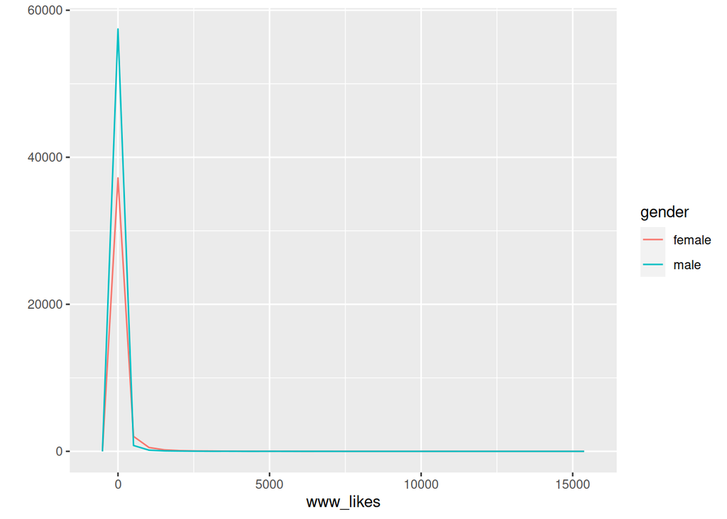

```r
qplot(x = www_likes, data=subset(pf, !is.na(gender)),
      geom = 'freqpoly', color = gender) +
  scale_x_continuous()
```

This is long-tail data so let’s use log()

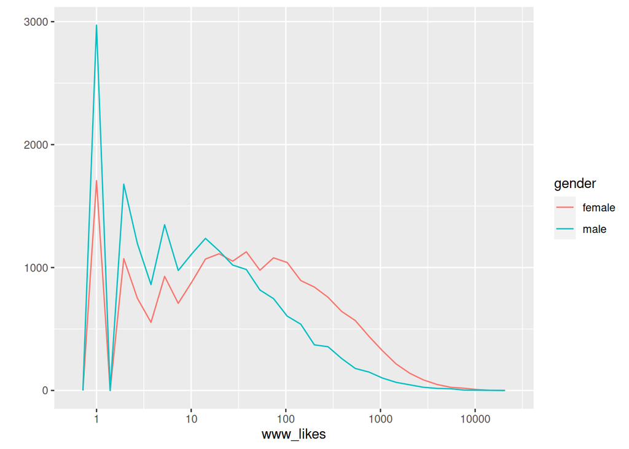

```r
qplot(x = www_likes, data=subset(pf, !is.na(gender)),
      geom = 'freqpoly', color = gender) +
  scale_x_continuous() +
  scale_x_log10()
```

Now we see at what point women overtake men in number of likes

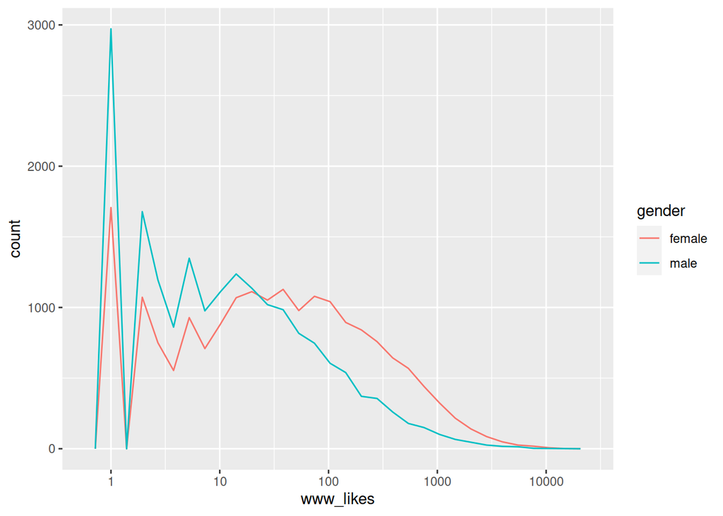

```r
ggplot(aes(x = www_likes), data = subset(pf, !is.na(gender))) +
  geom_freqpoly(aes(color = gender)) +
  scale_x_log10()
```

```r
by(pf$www_likes, pf$gender, sum)
```

```
## pf$gender: female
## [1] 3507665
## ------------------------------------------------------------
## pf$gender: male
## [1] 1430175
```

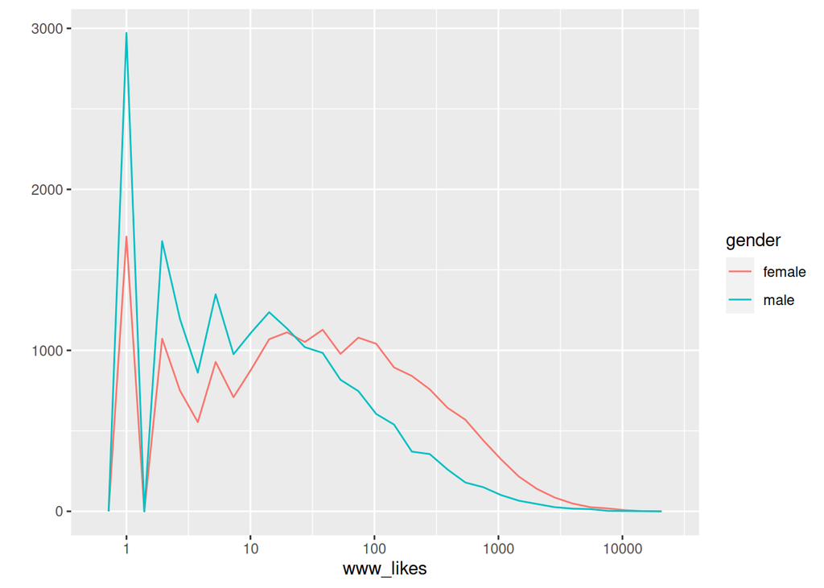

```r
qplot(x = www_likes, data=subset(pf, !is.na(gender)),
      geom = 'freqpoly', color = gender) +
  scale_x_continuous() +
  scale_x_log10()
```

### Box Plots

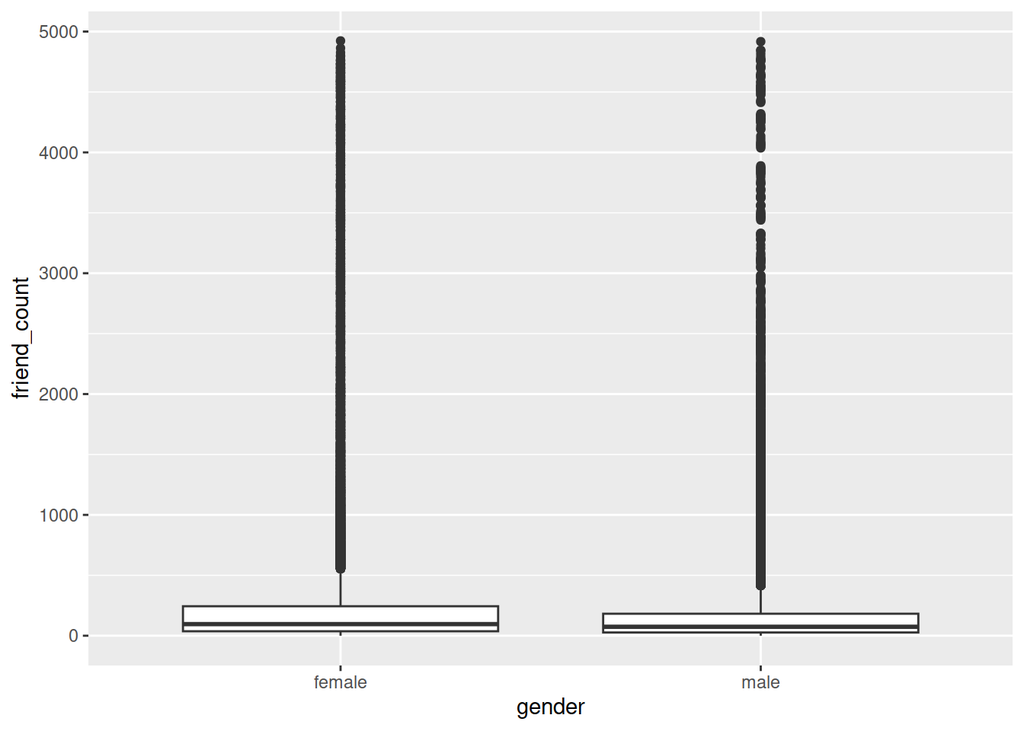

```r
qplot(x = gender,, y = friend_count,
      data=subset(pf, !is.na(gender)),
      geom = 'boxplot')
```

To ignore the outliers and focus on the box we can change the scale

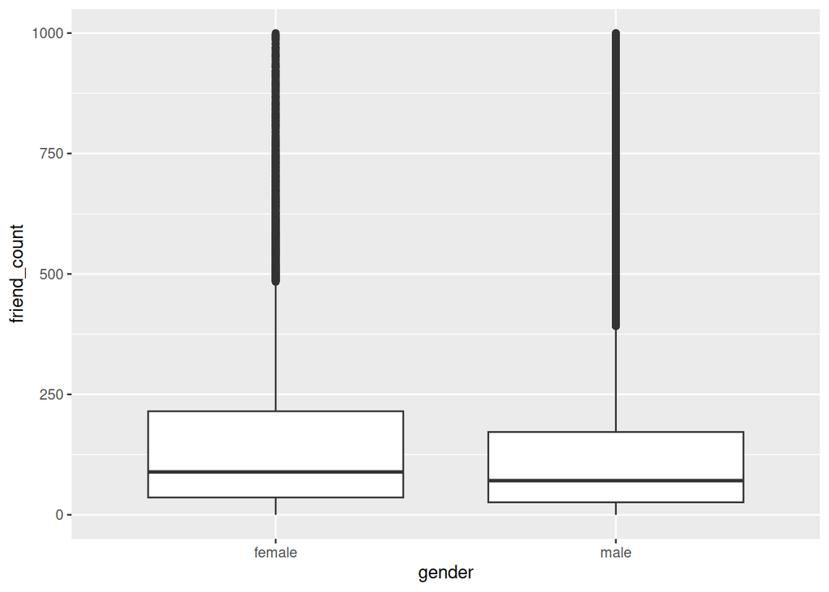

```r
qplot(x = gender,, y = friend_count,
      data=subset(pf, !is.na(gender)),
      geom = 'boxplot',
      ylim = c(0, 1000))
```

or

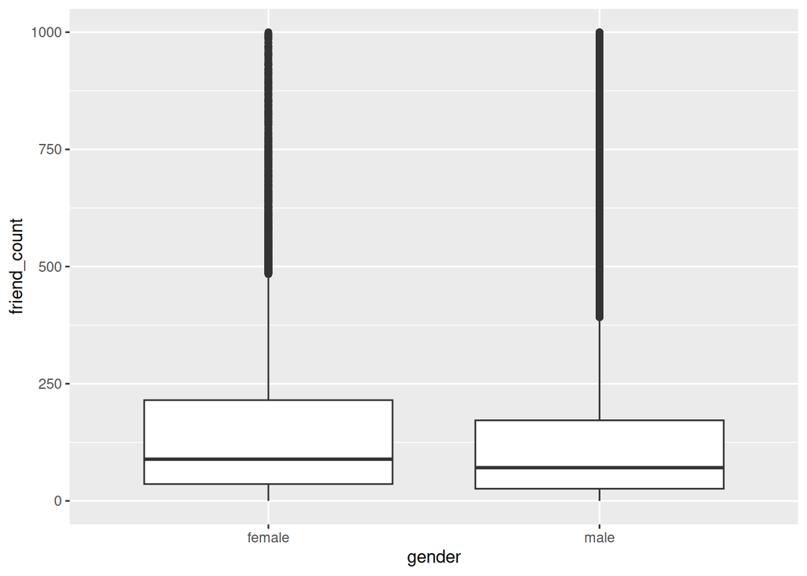

```r
qplot(x = gender,, y = friend_count,
      data=subset(pf, !is.na(gender)),
      geom = 'boxplot') +
  scale_y_continuous(limits = c(0, 1000))
```

Since we have removed data from the set the boundaries may be incorrect, so…

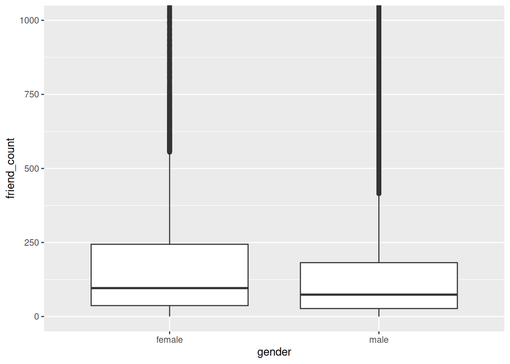

```r
qplot(x = gender,, y = friend_count,
      data=subset(pf, !is.na(gender)),
      geom = 'boxplot') +
  coord_cartesian(ylim = c(0, 1000))
```

Let’s zoom in more

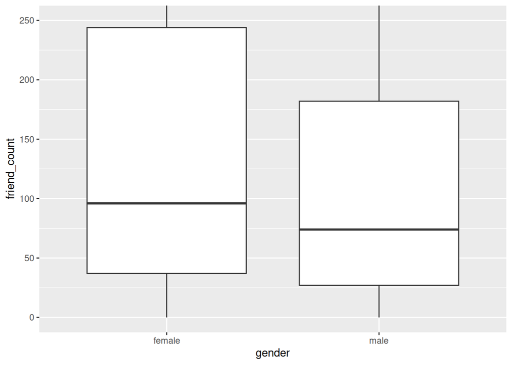

```r
qplot(x = gender,, y = friend_count,
      data=subset(pf, !is.na(gender)),
      geom = 'boxplot') +
  coord_cartesian(ylim = c(0, 250))
```

Lets look at the numbers (remember by(variable to report, variable to split, function))

```r
by(pf$friend_count, pf$gender, summary)
```

```
## pf$gender: female
##    Min. 1st Qu.  Median    Mean 3rd Qu.    Max.
##       0      37      96     242     244    4923
## ------------------------------------------------------------
## pf$gender: male
##    Min. 1st Qu.  Median    Mean 3rd Qu.    Max.
##       0      27      74     165     182    4917
```

#### Adjust the code to focus on users who have friend counts between 0 and 1000.

### Getting Logical

Notes:

```r
summary(pf$mobile_likes)
```

```
##    Min. 1st Qu.  Median    Mean 3rd Qu.    Max.
##     0.0     0.0     4.0   106.1    46.0 25111.0
```

The median of 4.0 shows that there are many 0 values

```r
summary(pf$mobile_likes > 0)
```

```
##    Mode   FALSE    TRUE
## logical   35056   63947
```

```r
mobile_checkin <- NA
pf$mobile_check_in <- ifelse(pf$mobile_likes > 0, 1, 0)
pf$mobile_check_in <- factor(pf$mobile_check_in)
summary(pf$mobile_check_in)
```

```
##     0     1
## 35056 63947
```

What percent of check in using mobile?

```r
sum(pf$mobile_check_in == 1)/length(pf$mobile_check_in)
```

```
## [1] 0.6459097
```

Click **KnitHTML** to see all of your hard work and to have an html page of this lesson, your answers, and your notes!